# Proof of concept: ZDT4.mod

Jonathan Boualavong

# Description

This notebook uses a newly developed Gaussian Process-based method to solve for the near-optimal set of solutions for CO2 capture using proton coupled electron transfers (PCET) to drive pH swings. The work assumes that the redox molecule is a quinone, and restricts the search to only combinations of properties that a quinone is likely to have. After determining the restricted search space, the performance of CO2 capture, defined by minimum energy demand and the CO2 capture flux, will be determined using established thermodynamic and kinetics equations. The resulting Pareto frontier of this bi-objective problem is solved using the GPareto package, then characterized to define acceptable sub-optimal performance in the likely event that a compound with the exact specifications of any of the Pareto frontier estimates not exist. The near-optimal set will be solved using the established method (see other mathematical examples for details and description of the algorithm) to describe what criteria the optimal quinone and solution composition should have.

# Code

## Initialization

Clear the workspace and define the functions.

```r
# Setup
rm(list = ls())
# Visualization
library(dplyr)
library(ggplot2)
library(patchwork)
# Parallel processing
library(parallel)
library(doParallel)
# Gaussian processes
library(GPareto)
library(DiceKriging)
library(DiceOptim)
# Optimization
library(GA)
```

## Parameter space

Data for restricting the quinone features is based on results from Huynh et al. J Am Chem Soc. 2016 December 14; 138(49): 15903–15910. doi:10.1021/jacs.6b05797.

Remove points that are not likely to be stable within the electrochemcial window of water. For the process: Q + 2e- + 2H+ <-> QH2 We can roughly assume that the reduction reaction is competing with hydrogen evolution 2H+ + 2e- <-> H2 and the oxidation reaction is competing with oxygen evolution 2H2O + 4OH- <-> O2 + 4e-

Both of these reactions are pH dependent, so the cutoff values are not obvious. At the extreme, the reduction potential of hydrogen evolution will be at its highest (most likely to compete with the quinone reduction) at the lowest pH, which would typically be at the pH where carbonic acid makes up > 90% of the CO2 speciation (pH = 5.33). Similarly, the reduction potential of oxygen evolution will be at its lowest at the highest pH, which would be just above the hydroquinone’s buffer region (the higher of its pKas + 1).

Practically, the quinone electrochemistry has much faster kinetics than either gas evolution reaction in the absence of a specific water-splitting catalyst, so a tolerance of about 200 mV will be added to accommodate.

```r
# Load data and correlation plot package
quinone.data = read.csv(file = 'HuynhData.csv', skip = 1)

# Filter the data to only those whose reaction would be stable in water
## Hydrogen evolution
h2.evo = -59.2*1e-3 * 5.33
quinone.data = filter(quinone.data, E0.2 > h2.evo)

## Cutoff value for oxygen evolution
o2.evo = 1.229 + -59.2*1e-3*quinone.data$Pka.2+1
quinone.data = filter(quinone.data, E0.1 < o2.evo)

quinone.data
```

| QuinoneCode | R2 | R3 | R5 | R6 | E0.1 | E0.2 | Pka.2 | Pka.1 |
| --- | --- | --- | --- | --- | --- | --- | --- | --- |
| 1 | H | H | H | H | 0.099 | 0.023 | 11.40 | 9.85 |
| 2 | C6H5 | H | H | H | 0.072 | 0.052 | 10.88 | 8.50 |
| 3 | CH3 | H | H | H | 0.007 | -0.030 | 11.39 | 10.52 |
| 4 | C(CH3)3 | H | H | H | -0.041 | -0.096 | 12.25 | 10.40 |
| 5 | OCH3 | H | H | H | -0.039 | -0.049 | 11.27 | 9.53 |
| 6 | N(CH3)2 | H | H | H | -0.221 | -0.144 | 12.32 | 9.60 |
| 7 | NH2 | H | H | H | -0.193 | -0.117 | 11.16 | 9.50 |
| 8 | CH2CH3 | H | H | H | -0.025 | -0.068 | 11.71 | 10.32 |
| 9 | OH | H | H | H | 0.013 | -0.025 | 11.03 | 9.64 |
| 10 | OCH2CH3 | H | H | H | -0.070 | -0.069 | 11.51 | 9.13 |

[output cut: 117 more lines]

```r
# Correlation plot between the E0 and pka values
cor.mat = matrix(data = rep(0, 16), nrow = 4)
for(i in seq(from = 6, to = 9, by = 1)){
  for(j in seq(from = i, to = 9, by = 1)){
    cor.mat[i-5,j-5] = cor(x = quinone.data[,i], y = quinone.data[,j])
  }
}
cor.mat
```

```
     [,1]      [,2]       [,3]       [,4]
[1,]    1 0.8090796 -0.7714352 -0.8214661
[2,]    0 1.0000000 -0.8668815 -0.8659535
[3,]    0 0.0000000  1.0000000  0.8751782
[4,]    0 0.0000000  0.0000000  1.0000000
```

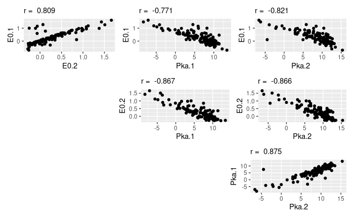

```r
g1 = ggplot(quinone.data) +
  geom_point(mapping = aes(y = E0.1, x = E0.2)) +
  labs(subtitle = paste('r = ', round(cor.mat[1,2], 3)))
g2 = ggplot(quinone.data) +
  geom_point(mapping = aes(y = E0.1, x = Pka.1)) +
  labs(subtitle = paste('r = ', round(cor.mat[1,3], 3)))
g3 = ggplot(quinone.data) +
  geom_point(mapping = aes(y = E0.1, x = Pka.2)) +
  labs(subtitle = paste('r = ', round(cor.mat[1,4], 3)))
g4 = ggplot(quinone.data) +
  geom_point(mapping = aes(y = E0.2, x = Pka.1)) +
  labs(subtitle = paste('r = ', round(cor.mat[2,3], 3)))
g5 = ggplot(quinone.data) +
  geom_point(mapping = aes(y = E0.2, x = Pka.2)) +
  labs(subtitle = paste('r = ', round(cor.mat[2,4], 3)))
g6 = ggplot(quinone.data) +
  geom_point(mapping = aes(y = Pka.1, x = Pka.2)) +
  labs(subtitle = paste('r = ', round(cor.mat[3,4], 3)))

(g1 + g2 + g3) / (plot_spacer() + g4 + g5) / (plot_spacer() + plot_spacer() + g6)
```

```r
rm(g1, g2, g3, g4, g5, g6)
rm(h2.evo, i, j, o2.evo, cor.mat)
```

While all four variables are strongly co-correlated, this is largely irrelevant because the thermodynamic and kinetic analyses do not rely on the reduction potential besides assuming that gas evolution does not occur. There is a Bronsted-like relationship between the reduction potential and the reaction rate of the deprotonated hydroquinone nucleophilically attacking the CO2 [Simpson & Durand 1990, doi: 10.1016/0013-4686(90)85012-C], but this is not likely to be the dominant mechanism because the reaction with OH- is approximately 10 to 100 times faster in water. To determine which pKa will be the free variable and which will be represented by an error term of the linear regression, the relative normalized standard deviations of the errors were compared.

```r
print('pka2 as free variable, pKa1 as the solved variable')
```

```
[1] "pka2 as free variable, pKa1 as the solved variable"
```

```r
mod1 = lm(Pka.1 ~ Pka.2, data = quinone.data)
sd(mod1$residuals[abs(mod1$residuals) < 10]) / diff(range(quinone.data$Pka.1))
```

```
[1] 0.07853397
```

```r
print('pka1 as free variable, pKa2 as the solved variable')
```

```
[1] "pka1 as free variable, pKa2 as the solved variable"
```

```r
mod2 = lm(Pka.2 ~ Pka.1, data = quinone.data)
sd(mod2$residuals[abs(mod2$residuals) < 10]) / diff(range(quinone.data$Pka.2))
```

```
[1] 0.070064
```

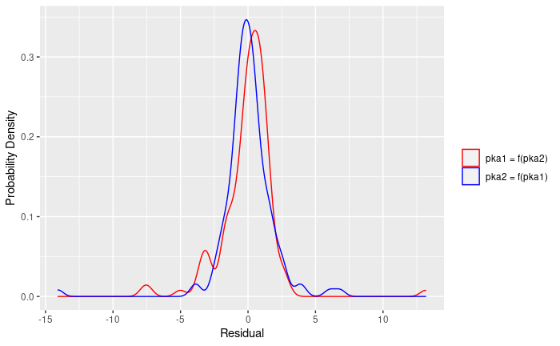

```r
x = c(unname(mod1$residuals), unname(mod2$residuals))
var = c(rep('pka1', length(mod1$residuals)), rep('pka2', length(mod1$residuals)))
ggplot(data.frame(x, var)) +
  geom_density(mapping = aes(x = x, color = var)) +
  scale_color_manual(labels = c('pka1' = 'pka1 = f(pka2)', 'pka2' = 'pka2 = f(pka1)'),
                     values = c('pka1' = 'red', 'pka2' = 'blue'), name = '') +
  labs(x = 'Residual', y = 'Probability Density')
```

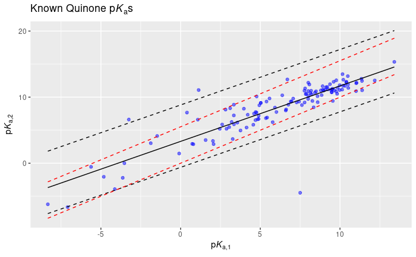

```r
# Determine the value for the standard deviation that should be used to encompass 98% of the search space
q1 = quantile(mod2$residuals, probs = c(0.01))
q2 = quantile(mod2$residuals, probs = c(0.99))
# Plot the data and the search space
fit.ln = data.frame(Pka.1 = seq(from = -8.33, to = 13.41, length.out = 3))
fit.ln$Pka.2 = predict(object = mod2, newdata = fit.ln)
ggplot() +
  geom_point(quinone.data, mapping = aes(x = Pka.1, y = Pka.2), color = 'blue', alpha = 0.5) +
  geom_line(fit.ln, mapping = aes(x = Pka.1, y = Pka.2), color = 'black', linetype = 1) +
  geom_line(fit.ln, mapping = aes(x = Pka.1, y = Pka.2+q2), color = 'black', linetype = 2) +
  geom_line(fit.ln, mapping = aes(x = Pka.1, y = Pka.2+q1), color = 'black', linetype = 2) +
  geom_line(fit.ln, mapping = aes(x = Pka.1, y = Pka.1), color = 'red', linetype = 2) +
  geom_line(fit.ln, mapping = aes(x = Pka.1, y = Pka.1+q2), color = 'red', linetype = 2) +
  labs(title = expression('Known Quinone p'*italic(K)*''[a]*'s'),
       y = expression('p'*italic(K)*''['a,2']),
       x = expression('p'*italic(K)*''['a,1']))
```

```r
q1
```

```
       1%
-3.932909
```

```r
q2
```

```
     99%
5.510746
```

```r
rm(fit.ln, x, var)
```

The variance alone show very little difference between the choice, which pKa1 being the free variable having a slightly better response. This is confirmed by the distribution of the residuals (omitting the single outlier), which shows that having pKa1 as the free variable gives a distribution closer to a normal distribution. Therefore, the range of pKas is:

pKa1: -8.33 to 13.41 pKa2 = f(pKa1) + error

While the error for pKa2 is nearly Gaussian in shape, the mathematical description works better if it is sampled from a uniform distribution. From the data, 98% of the data is captured within an error of -3.9 to +5.5.

This range of pKas has 2 problems: * An issue seems to arise when the second pKa is lower than the first, however, despite some actual measurements violating that criteria (red dotted line). All points that do violate that restriction are within measurement error with one exception, so that could be the cause. * The pH of the process is not likely to extend below 3 because the primary acid in question is carbonic acid. This means that pKa values below 2 are effectively the same and do not need to be sampled further. Therefore, the lower bound for pKa1 can be increased to reduce the search space.

The refined search space is: